# Unbounded Implicit Learning - Analysis

Shanaa Modchalingam

2022-04-04

# 1 Some backround

A few studies show that implicit adaptation is ‘rigid’. ‘Rigid’ in this context means an upper boundary on adaptation.

These studies include (but are not limited to)

### 1.0.1 Bond & Taylor (2015)

Here, people adapted to visuomotor rotations and provided aiming directions **prior** to every reach. Implicit learning was measured by subtracting the aiming direction from the direction of movement.

**Movement type:** Balistic movements (<400 ms) and end-point feedback  
**Target parameters:** 7 cm distance, radial target locations  
**Other:** Participants were reminded “always moving directly to the target may not be effective” every 40 trials

**Interesting tidbits:** training to 1 target actually resulted in higher implicit learning (30°!). 2 and 4 targets resulted in 17 - 20°.  
Final implicit learning was ~10° for 15, 30, 60 and 90° rotations – this did not differ between groups.

### 1.0.2 Kim et al. (2019)

**Movement type:** Clamped. Slicing movements (<300 ms)  
**Target parameters:** 8 cm distance, radial target locations, 8 targets (in exp 1) or 4 targets (in exp 2)  
**Other:** Patricipants were instructed to ignore the visual error.

**Interesting tidbits:**

### 1.0.3 Modchalingam et al. (2019)

**Movement type:** Non-balistic  
**Target parameters:** 12 cm distance, located 45, 90, 135 degrees in polar coordinates  
**Other:**

**Interesting tidbits:**

# 2 No-cursor analysis

## 2.1 Load and summarize data

### 2.1.1 Load the baseline corrected data

Load in the data frame, then separate for easier plotting

```r
# load in the large df
rot_all <- read_delim("data/bl_corrected/bl_corrected_data.csv",
                               delim = ",",
                               col_types = cols(.default = col_double(),
                                                targetangle_deg = col_factor(),
                                                strat_use = col_factor(),
                                                ppt = col_factor(),
                                                exp = col_factor(),
                                                block_num = col_factor(),
                                                trial_set = col_factor(),
                                                reach_type = col_factor()))

# separate the nocursor and training data
rot_nocur <- rot_all %>%
  filter(reach_type == "nocursor")

rot_training <- rot_all %>%
  filter(reach_type == "reach")
```

```r
# palette
cbp1 <- c("#ff8000", "#e51636", "#0500a0")
```

The column of interest is “angular_dev”. It contains, in degrees, the amount participants deviated from a straight-line reach towards the target.

### 2.1.2 Make a summary file with means for each participant

Each participant has 8 means: 2 for each block (one for each strategy use)

```r
nocur_summary <- rot_nocur %>%
  group_by(exp, ppt, block_num, strat_use) %>%
  summarise(mean_devs = mean(angular_dev),
            sd = sd(angular_dev),
            ci = vector_confint(angular_dev),
            n = n(), .groups = "drop")

head(nocur_summary)
```

| exp | ppt | block_num | strat_use | mean_devs | sd | ci | n |
| --- | --- | --- | --- | --- | --- | --- | --- |
| abrupt | 001_longAbruptExp | 1 | 0 | 14.22070 | 6.916284 | 3.439387 | 18 |
| abrupt | 001_longAbruptExp | 1 | 1 | 13.64109 | 11.809881 | 5.872916 | 18 |
| abrupt | 001_longAbruptExp | 2 | 0 | 10.44513 | 9.003424 | 4.477297 | 18 |
| abrupt | 001_longAbruptExp | 2 | 1 | 19.95736 | 11.963222 | 5.949170 | 18 |
| abrupt | 001_longAbruptExp | 3 | 0 | 17.27364 | 6.624168 | 3.294121 | 18 |
| abrupt | 001_longAbruptExp | 3 | 1 | 20.68505 | 14.126197 | 7.024792 | 18 |

## 2.2 Statistics

### 2.2.1 OMNIBUS ANOVA

We do a 3x4x2 mixed ANOVA (experiment x block x strategy use)

```r
#show and ANOVA + assumptions
print(temp_ANOVA$ANOVA)
```

|  | Effect | DFn | DFd | SSn | SSd | F | p | p<.05 | ges |
| --- | --- | --- | --- | --- | --- | --- | --- | --- | --- |
| 1 | (Intercept) | 1 | 102 | 241013.4154 | 44713.765 | 549.794193 | 7.107768e-43 | * | 0.70000195 |
| 2 | exp | 2 | 102 | 1601.7726 | 44713.765 | 1.826963 | 1.661273e-01 |  | 0.01527064 |
| 3 | block_num | 3 | 306 | 11414.2440 | 12607.297 | 92.347541 | 1.409506e-42 | * | 0.09950978 |
| 5 | strat_use | 1 | 102 | 13624.0961 | 37093.037 | 37.464115 | 1.747038e-08 | * | 0.11653032 |
| 4 | exp:block_num | 6 | 306 | 7052.9813 | 12607.297 | 28.531258 | 4.703428e-27 | * | 0.06391842 |
| 6 | exp:strat_use | 2 | 102 | 3274.0712 | 37093.037 | 4.501590 | 1.338143e-02 | * | 0.03072382 |
| 7 | block_num:strat_use | 3 | 306 | 1543.9995 | 8876.406 | 17.742311 | 1.210803e-10 | * | 0.01472797 |
| 8 | exp:block_num:strat_use | 6 | 306 | 537.0001 | 8876.406 | 3.085371 | 6.009949e-03 | * | 0.00517204 |

### 2.2.2 Implicit aftereffects

We will do 2 sets of analyses for all sets of data. First, we compare our measures in blocks where they first hit 60-degree rotations. Then, we compare block 4 in all groups (time = same).

*3x4 ANOVA (experiment x block)*

```r
#show and ANOVA + assumptions
print(temp_ANOVA$ANOVA)
```

|  | Effect | DFn | DFd | SSn | SSd | F | p | p<.05 | ges |
| --- | --- | --- | --- | --- | --- | --- | --- | --- | --- |
| 1 | (Intercept) | 1 | 102 | 70016.139 | 9678.11 | 737.917438 | 1.685221e-48 | * | 0.82798399 |
| 2 | exp | 2 | 102 | 1084.063 | 9678.11 | 5.712603 | 4.450620e-03 | * | 0.06935732 |
| 3 | block_num | 3 | 306 | 2368.129 | 4867.94 | 49.620399 | 3.682072e-26 | * | 0.14000850 |
| 4 | exp:block_num | 6 | 306 | 2581.443 | 4867.94 | 27.045026 | 7.876936e-26 | * | 0.15071923 |

To test whether the method of perturbation onset effected implicit learning, we compared the aftereffects of learning in No-Strategy trials.

*Early Implicit Aftereffects* These are aftereffects measured during the blocks in which participants first encounter a 60-degree rotation.

```r
wo_strat_init_blocks <- nocur_summary %>%
  filter(strat_use == '0') %>% #only the implicit aftereffects
  filter((exp == 'stepped' & block_num == '4') | #only the 5 blocks (1 and 4)
         (exp == 'abrupt' & block_num == '1') |
         (exp == 'ramped' & block_num == '1'))
```

Plot

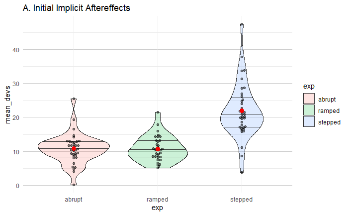

```r
plot_desc_group_density(wo_strat_init_blocks, "exp", "mean_devs", title = "A. Initial Implicit Aftereffects")
```

Descriptive stats

```r
wo_strat_init_blocks %>%
  group_by(exp) %>%
  summarise(mean = mean(mean_devs),
            sd = sd(mean_devs),
            ci = vector_confint(mean_devs),
            n = n())
```

| exp | mean | sd | ci | n |
| --- | --- | --- | --- | --- |
| abrupt | 10.76370 | 4.499413 | 1.545602 | 35 |
| ramped | 10.74201 | 3.716661 | 1.317871 | 33 |
| stepped | 21.96356 | 8.069290 | 2.690435 | 37 |

ANOVA and post-hoc test

```r
temp_ANOVA <- aov(mean_devs ~ exp, data = wo_strat_init_blocks)

#show ANOVA + assumptions
print(summary(temp_ANOVA), digits = 6)
```

```
             Df  Sum Sq  Mean Sq F value     Pr(>F)
exp           2 3011.36 1505.682 44.2027 1.4961e-14 ***
Residuals   102 3474.44   34.063
---
Signif. codes:  0 ‘***’ 0.001 ‘**’ 0.01 ‘*’ 0.05 ‘.’ 0.1 ‘ ’ 1
```

```r
eta_squared(temp_ANOVA)
```

```
For one-way between subjects designs, partial eta squared is equivalent to eta squared. Returning eta squared.
```

```
# Effect Size for ANOVA

Parameter | Eta2 |       95% CI
-------------------------------
exp       | 0.46 | [0.35, 1.00]

- One-sided CIs: upper bound fixed at [1.00].
```

```r
TukeyHSD(temp_ANOVA)
```

```
  Tukey multiple comparisons of means
    95% family-wise confidence level

Fit: aov(formula = mean_devs ~ exp, data = wo_strat_init_blocks)

$exp
                      diff       lwr       upr     p adj
ramped-abrupt  -0.02169272 -3.389849  3.346463 0.9998706
stepped-abrupt 11.19985301  7.926747 14.472959 0.0000000
stepped-ramped 11.22154573  7.897860 14.545231 0.0000000
```

Bayes Factors

```r
bf <- anovaBF(mean_devs ~ exp, data = data.frame(wo_strat_init_blocks), progress=FALSE)
```

[output not shown]

```r
print(bf)
```

```
Bayes factor analysis
--------------
[1] exp : NA ±NA%

Against denominator:
  Intercept only
---
Bayes factor type: BFlinearModel, JZS
```

```r
bayesfactor_inclusion(bf)
```

```
Inclusion Bayes Factors (Model Averaged)

    P(prior) P(posterior) Inclusion BF
exp     0.50            0

* Compared among: all models
*    Priors odds: uniform-equal
```

```r
print(tmp_bf_abr_ramp)
```

```
[1] "BF10: 0.249, P(D|H0): 0.801, P(D|H1): 0.199, Groups: abrupt vs ramped"
```

```r
print(tmp_bf_stp_ramp)
```

```
[1] "BF10: 20366836.741, P(D|H0): 0.000, P(D|H1): 1.000, Groups: stepped vs ramped"
```

```r
print(tmp_bf_stp_abr)
```

```
[1] "BF10: 15472147.953, P(D|H0): 0.000, P(D|H1): 1.000, Groups: stepped vs abrupt"
```

2. Time-constant measures

```r
wo_strat_final_blocks <- nocur_summary %>%
  filter(strat_use == '0') %>% #only the implicit aftereffects
  filter(block_num == '4') # only comparing block 4 data
```

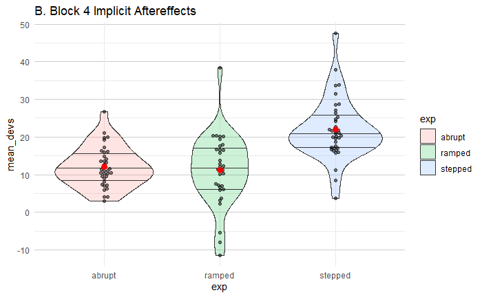

```r
#plot
plot_desc_group_density(wo_strat_final_blocks, "exp", "mean_devs", title = "B. Block 4 Implicit Aftereffects")
```

```r
# descriptives
wo_strat_final_blocks %>%
  group_by(exp) %>%
  summarise(mean = mean(mean_devs),
            sd = sd(mean_devs),
            ci = vector_confint(mean_devs),
            n = n())
```

| exp | mean | sd | ci | n |
| --- | --- | --- | --- | --- |
| abrupt | 12.03845 | 5.336865 | 1.833277 | 35 |
| ramped | 11.17875 | 9.382059 | 3.326733 | 33 |
| stepped | 21.96356 | 8.069290 | 2.690435 | 37 |

```r
no_cur_ANOVA <- aov(mean_devs ~ exp, data = wo_strat_final_blocks)

#show ANOVA + assumptions
print(summary(no_cur_ANOVA), digits = 6)
```

```
             Df  Sum Sq Mean Sq F value     Pr(>F)
exp           2 2575.60 1287.80 21.4311 1.6979e-08 ***
Residuals   102 6129.21   60.09
---
Signif. codes:  0 ‘***’ 0.001 ‘**’ 0.01 ‘*’ 0.05 ‘.’ 0.1 ‘ ’ 1
```

```r
eta_squared(no_cur_ANOVA)
```

```
For one-way between subjects designs, partial eta squared is equivalent to eta squared. Returning eta squared.
```

```
# Effect Size for ANOVA

Parameter | Eta2 |       95% CI
-------------------------------
exp       | 0.30 | [0.17, 1.00]

- One-sided CIs: upper bound fixed at [1.00].
```

```r
TukeyHSD(no_cur_ANOVA)
```

```
  Tukey multiple comparisons of means
    95% family-wise confidence level

Fit: aov(formula = mean_devs ~ exp, data = wo_strat_final_blocks)

$exp
                    diff       lwr       upr     p adj
ramped-abrupt  -0.859701 -5.333251  3.613849 0.8913680
stepped-abrupt  9.925106  5.577801 14.272412 0.0000011
stepped-ramped 10.784807  6.370323 15.199291 0.0000002
```

Bayes Factors

```r
anovaBF(mean_devs ~ exp, data = wo_strat_final_blocks, progress=FALSE)
```

```
Bayes factor analysis
--------------
[1] exp : NA ±NA%

Against denominator:
  Intercept only
---
Bayes factor type: BFlinearModel, JZS
```

```r
print(tmp_bf_abr_ramp)
```

```
[1] "BF10: 0.274, P(D|H0): 0.785, P(D|H1): 0.215, Groups: abrupt vs ramped"
```

```r
print(tmp_bf_stp_ramp)
```

```
[1] "BF10: 6566.380, P(D|H0): 0.000, P(D|H1): 1.000, Groups: stepped vs ramped"
```

```r
print(tmp_bf_stp_abr)
```

```
[1] "BF10: 219838.834, P(D|H0): 0.000, P(D|H1): 1.000, Groups: stepped vs abrupt"
```

### 2.2.3 Explicit strategy

Same analysis pipeline as for the implicit measures

First, we need to actually calculate strategy

```r
#first get explicit strat for each ppt

nocur_summary_wide <- nocur_summary %>%
  select(-sd, -ci) %>%
  pivot_wider(names_from = "strat_use",
              values_from = mean_devs,
              names_prefix = "strat_") %>%
  mutate(strategy = strat_1 - strat_0)
```

1. Initial measures

```r
strat_initial_blocks <- nocur_summary_wide %>%
  filter((exp == 'stepped' & block_num == '4') | #only the 5 blocks (1 and 4)
         (exp == 'abrupt' & block_num == '1') |
         (exp == 'ramped' & block_num == '1'))
```

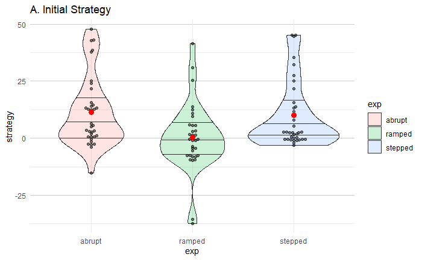

```r
#plot
plot_desc_group_density(strat_initial_blocks, "exp", "strategy", title = "A. Initial Strategy")
```

```r
# descriptives
strat_initial_blocks %>%
  group_by(exp) %>%
  summarise(mean = mean(strategy),
            sd = sd(strategy),
            ci = vector_confint(strategy),
            n = n())
```

| exp | mean | sd | ci | n |
| --- | --- | --- | --- | --- |
| abrupt | 11.2560999 | 15.34160 | 5.270024 | 35 |
| ramped | 0.3058419 | 15.09800 | 5.353516 | 33 |
| stepped | 10.0736529 | 14.48283 | 4.828816 | 37 |

```r
no_cur_ANOVA <- aov(strategy ~ exp, data = strat_initial_blocks)

#show ANOVA + assumptions
print(summary(no_cur_ANOVA), digits = 6)
```

```
             Df   Sum Sq  Mean Sq F value    Pr(>F)
exp           2  2445.72 1222.859 5.45922 0.0055924 **
Residuals   102 22847.87  223.999
---
Signif. codes:  0 ‘***’ 0.001 ‘**’ 0.01 ‘*’ 0.05 ‘.’ 0.1 ‘ ’ 1
```

```r
eta_squared(no_cur_ANOVA)
```

```
For one-way between subjects designs, partial eta squared is equivalent to eta squared. Returning eta squared.
```

```
# Effect Size for ANOVA

Parameter | Eta2 |       95% CI
-------------------------------
exp       | 0.10 | [0.02, 1.00]

- One-sided CIs: upper bound fixed at [1.00].
```

```r
TukeyHSD(no_cur_ANOVA)
```

```
  Tukey multiple comparisons of means
    95% family-wise confidence level

Fit: aov(formula = strategy ~ exp, data = strat_initial_blocks)

$exp
                     diff        lwr       upr     p adj
ramped-abrupt  -10.950258 -19.587453 -2.313063 0.0090139
stepped-abrupt  -1.182447  -9.575899  7.211005 0.9400295
stepped-ramped   9.767811   1.244655 18.290967 0.0204685
```

Bayes Factors

```r
anovaBF(strategy ~ exp, data = strat_initial_blocks, progress=FALSE)
```

```
Bayes factor analysis
--------------
[1] exp : NA ±NA%

Against denominator:
  Intercept only
---
Bayes factor type: BFlinearModel, JZS
```

```r
print(tmp_bf_abr_ramp)
```

```
[1] "BF10: 9.278, P(D|H0): 0.097, P(D|H1): 0.903, Groups: abrupt vs ramped"
```

```r
print(tmp_bf_stp_ramp)
```

```
[1] "BF10: 5.849, P(D|H0): 0.146, P(D|H1): 0.854, Groups: stepped vs ramped"
```

```r
print(tmp_bf_stp_abr)
```

```
[1] "BF10: 0.255, P(D|H0): 0.797, P(D|H1): 0.203, Groups: stepped vs abrupt"
```

2. Same but for the final block

```r
strat_final_blocks <- nocur_summary_wide %>%
  filter(block_num == '4')
```

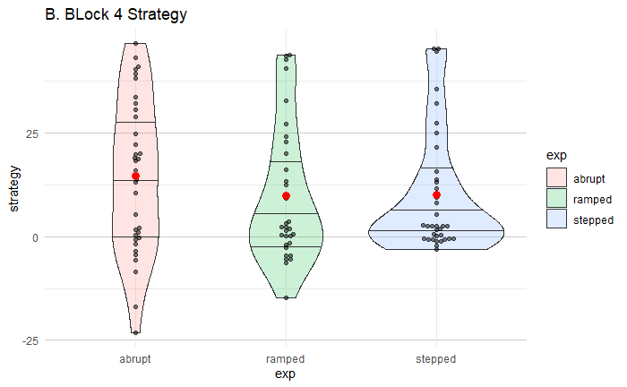

```r
#plot
plot_desc_group_density(strat_final_blocks, "exp", "strategy", title = "B. BLock 4 Strategy")
```

```r
# descriptives
strat_final_blocks %>%
  group_by(exp) %>%
  summarise(mean = mean(strategy),
            sd = sd(strategy),
            ci = vector_confint(strategy),
            n = n())
```

| exp | mean | sd | ci | n |
| --- | --- | --- | --- | --- |
| abrupt | 14.707702 | 18.25561 | 6.271021 | 35 |
| ramped | 9.916184 | 16.32829 | 5.789761 | 33 |
| stepped | 10.073653 | 14.48283 | 4.828816 | 37 |

```r
no_cur_ANOVA <- aov(strategy ~ exp, data = strat_final_blocks)

#show ANOVA + assumptions
print(summary(no_cur_ANOVA), digits = 6)
```

```
             Df   Sum Sq Mean Sq F value  Pr(>F)
exp           2   517.68 258.842 0.96309 0.38516
Residuals   102 27413.79 268.763
```

```r
eta_squared(no_cur_ANOVA)
```

```
For one-way between subjects designs, partial eta squared is equivalent to eta squared. Returning eta squared.
```

```
# Effect Size for ANOVA

Parameter | Eta2 |       95% CI
-------------------------------
exp       | 0.02 | [0.00, 1.00]

- One-sided CIs: upper bound fixed at [1.00].
```

```r
TukeyHSD(no_cur_ANOVA)
```

```
  Tukey multiple comparisons of means
    95% family-wise confidence level

Fit: aov(formula = strategy ~ exp, data = strat_final_blocks)

$exp
                     diff       lwr      upr     p adj
ramped-abrupt  -4.7915177 -14.25246 4.669426 0.4532287
stepped-abrupt -4.6340488 -13.82800 4.559906 0.4566252
stepped-ramped  0.1574689  -9.17856 9.493498 0.9991131
```

Bayes Factors

```r
anovaBF(strategy ~ exp, data = strat_final_blocks, progress=FALSE)
```

```
Bayes factor analysis
--------------
[1] exp : NA ±NA%

Against denominator:
  Intercept only
---
Bayes factor type: BFlinearModel, JZS
```

```r
print(tmp_bf_abr_ramp)
```

```
[1] "BF10: 0.432, P(D|H0): 0.698, P(D|H1): 0.302, Groups: abrupt vs ramped"
```

```r
print(tmp_bf_stp_ramp)
```

```
[1] "BF10: 0.247, P(D|H0): 0.802, P(D|H1): 0.198, Groups: stepped vs ramped"
```

```r
print(tmp_bf_stp_abr)
```

```
[1] "BF10: 0.449, P(D|H0): 0.690, P(D|H1): 0.310, Groups: stepped vs abrupt"
```

3. Compare strategy use in blocks 1 and 4 for abrupt and ramp data

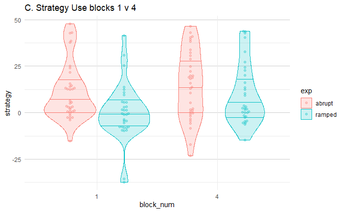

```r
strat_betwn_block <- nocur_summary_wide %>%
  filter(block_num == '4' | block_num =='1', exp == 'abrupt' | exp == 'ramped')

plot_desc_group_density(strat_betwn_block, "block_num", "strategy", subgroup = "exp", title = "C. Strategy Use blocks 1 v 4")
```

```r
anovaBF(strategy ~ exp * block_num, data = strat_betwn_block, progress=FALSE)
```

```
Bayes factor analysis
--------------
[1] exp                             : 5.66803  ±0%
[2] block_num                       : 1.778223 ±0.01%
[3] exp + block_num                 : NA       ±NA%
[4] exp + block_num + exp:block_num : NA       ±NA%

Against denominator:
  Intercept only
---
Bayes factor type: BFlinearModel, JZS
```

```r
btwn_block_strat_ANOVA <- aov(strategy ~ exp * block_num, data = strat_betwn_block)
print(summary(btwn_block_strat_ANOVA), digits = 6)
```

```
               Df  Sum Sq  Mean Sq F value    Pr(>F)
exp             1  2104.5 2104.508 7.90100 0.0056939 **
block_num       1  1410.3 1410.279 5.29464 0.0229584 *
exp:block_num   1   322.1  322.127 1.20937 0.2734590
Residuals     132 35159.5  266.360
---
Signif. codes:  0 ‘***’ 0.001 ‘**’ 0.01 ‘*’ 0.05 ‘.’ 0.1 ‘ ’ 1
```

```r
eta_squared(btwn_block_strat_ANOVA)
```

```
# Effect Size for ANOVA (Type I)

Parameter     | Eta2 (partial) |       95% CI
---------------------------------------------
exp           |           0.06 | [0.01, 1.00]
block_num     |           0.04 | [0.00, 1.00]
exp:block_num |       9.08e-03 | [0.00, 1.00]

- One-sided CIs: upper bound fixed at [1.00].
```

```r
TukeyHSD(btwn_block_strat_ANOVA)
```

```
  Tukey multiple comparisons of means
    95% family-wise confidence level

Fit: aov(formula = strategy ~ exp * block_num, data = strat_betwn_block)

$exp
                   diff       lwr       upr     p adj
ramped-abrupt -7.870888 -13.40988 -2.331895 0.0056939

$block_num
        diff      lwr    upr     p adj
4-1 6.440402 0.903806 11.977 0.0229584

$`exp:block_num`
                        diff         lwr        upr     p adj
ramped:1-abrupt:1 -10.950258 -21.2544791 -0.6460368 0.0325684
abrupt:4-abrupt:1   3.451602  -6.6999558 13.6031594 0.8127932
ramped:4-abrupt:1  -1.339916 -11.6441371  8.9643053 0.9866055
abrupt:4-ramped:1  14.401860   4.0976386 24.7060809 0.0022089
ramped:4-ramped:1   9.610342  -0.8443137 20.0649977 0.0836037
ramped:4-abrupt:4  -4.791518 -15.0957388  5.5127035 0.6216398
```

## 2.3 Analysis of low strategy use

```r
# first tag people with low strategy in block 4
nocur_summary_wide <- nocur_summary_wide %>%
  mutate(block_4_strat = case_when(block_num == 4 & strategy > 5 ~ 1,
         block_num == 4 & strategy <= 5 ~ 0)) %>%
  fill(block_4_strat, .direction = "up")

nocur_summary_wide$block_4_strat = as.factor(nocur_summary_wide$block_4_strat)

block_4_nocur <- nocur_summary_wide %>%
  filter(block_num == 4)
```

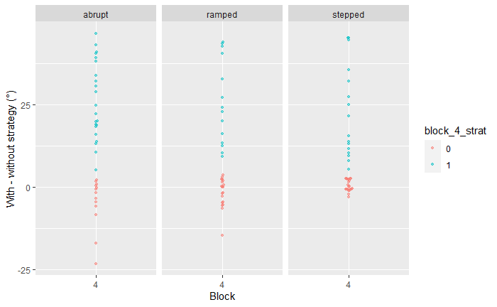

```r
# plot
p <- block_4_nocur %>%
  ggplot(aes(block_num, strategy)) +
  geom_beeswarm(
    aes(colour = block_4_strat),
    alpha = 0.5,
    size = 1
    ) +
  facet_grid(~exp) +
        xlab("Block") + ylab("With - without strategy (°)")

p
```

Number of individuals without strategy

```r
block_4_nocur %>%
  group_by(exp, block_4_strat) %>%
  summarise(n = n(), .groups = "drop")
```

| exp | block_4_strat | n |
| --- | --- | --- |
| abrupt | 0 | 13 |
| abrupt | 1 | 22 |
| ramped | 0 | 19 |
| ramped | 1 | 14 |
| stepped | 0 | 21 |
| stepped | 1 | 16 |

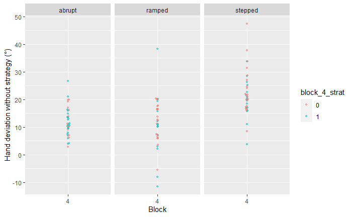

```r
# plot
p <- block_4_nocur %>%
  ggplot(aes(block_num, strat_0)) +
  geom_beeswarm(
    aes(colour = block_4_strat),
    alpha = 0.5,
    size = 1
    ) +
  facet_grid(~exp)+
        xlab("Block") + ylab("Hand deviation without strategy (°)")

p
```

```r
block_4_strat_aov <- aov(strat_0 ~ exp * block_4_strat, data = block_4_nocur)
print(summary(block_4_strat_aov), digits = 6)
```

```
                  Df  Sum Sq  Mean Sq  F value     Pr(>F)
exp                2 2575.60 1287.801 21.34386 1.9634e-08 ***
block_4_strat      1  120.88  120.884  2.00351    0.16007
exp:block_4_strat  2   35.08   17.538  0.29067    0.74840
Residuals         99 5973.25   60.336
---
Signif. codes:  0 ‘***’ 0.001 ‘**’ 0.01 ‘*’ 0.05 ‘.’ 0.1 ‘ ’ 1
```

```r
eta_squared(block_4_strat_aov)
```

```
# Effect Size for ANOVA (Type I)

Parameter         | Eta2 (partial) |       95% CI
-------------------------------------------------
exp               |           0.30 | [0.18, 1.00]
block_4_strat     |           0.02 | [0.00, 1.00]
exp:block_4_strat |       5.84e-03 | [0.00, 1.00]

- One-sided CIs: upper bound fixed at [1.00].
```

```r
TukeyHSD(block_4_strat_aov)
```

```
  Tukey multiple comparisons of means
    95% family-wise confidence level

Fit: aov(formula = strat_0 ~ exp * block_4_strat, data = block_4_nocur)

$exp
                    diff       lwr       upr     p adj
ramped-abrupt  -0.859701 -5.344390  3.624988 0.8917882
stepped-abrupt  9.925106  5.566976 14.283237 0.0000013
stepped-ramped 10.784807  6.359330 15.210284 0.0000002

$block_4_strat
         diff       lwr       upr     p adj
1-0 -2.107497 -5.115873 0.9008786 0.1676374

$`exp:block_4_strat`
                           diff         lwr       upr     p adj
ramped:0-abrupt:0    -0.5928748  -8.7184607  7.532711 0.9999393
stepped:0-abrupt:0   10.9748025   3.0079585 18.941646 0.0016434
abrupt:1-abrupt:0    -0.8465876  -8.7438976  7.050722 0.9995967
ramped:1-abrupt:0    -2.4761542 -11.1712499  6.218941 0.9617133
stepped:1-abrupt:0    7.3168039  -1.1125737 15.746181 0.1274838
stepped:0-ramped:0   11.5676773   4.4198883 18.715466 0.0001190
abrupt:1-ramped:0    -0.2537129  -7.3239172  6.816491 0.9999982
ramped:1-ramped:0    -1.8832795  -9.8346928  6.068134 0.9828683
stepped:1-ramped:0    7.9096787   0.2497380 15.569619 0.0387804
abrupt:1-stepped:0  -11.8213901 -18.7085699 -4.934210 0.0000378
ramped:1-stepped:0  -13.4509567 -21.2400792 -5.661834 0.0000333
stepped:1-stepped:0  -3.6579986 -11.1493367  3.833340 0.7153905
ramped:1-abrupt:1    -1.6295666  -9.3475540  6.088421 0.9898126
stepped:1-abrupt:1    8.1633915   0.7460438 15.580739 0.0222207
stepped:1-ramped:1    9.7929581   1.5313461 18.054570 0.0105723
```

```r
# t-test to determine if implicit learning was different in strategy users

res <- t.test(strat_0 ~ block_4_strat, data = filter(block_4_nocur, exp == "stepped"), var.equal = FALSE)
res
```

```
    Welch Two Sample t-test

data:  strat_0 by block_4_strat
t = 1.4234, df = 34.825, p-value = 0.1635
alternative hypothesis: true difference in means between group 0 and group 1 is not equal to 0
95 percent confidence interval:
 -1.560014  8.876011
sample estimates:
mean in group 0 mean in group 1
       23.54539        19.88739
```

```r
# t-test to determine if implicit learning was different in strategy users

res <- t.test(strat_0 ~ block_4_strat, data = block_4_nocur, var.equal = FALSE)
res
```

```
    Welch Two Sample t-test

data:  strat_0 by block_4_strat
t = 1.6428, df = 103, p-value = 0.1035
alternative hypothesis: true difference in means between group 0 and group 1 is not equal to 0
95 percent confidence interval:
 -0.6030712  6.4220132
sample estimates:
mean in group 0 mean in group 1
       16.70656        13.79709
```

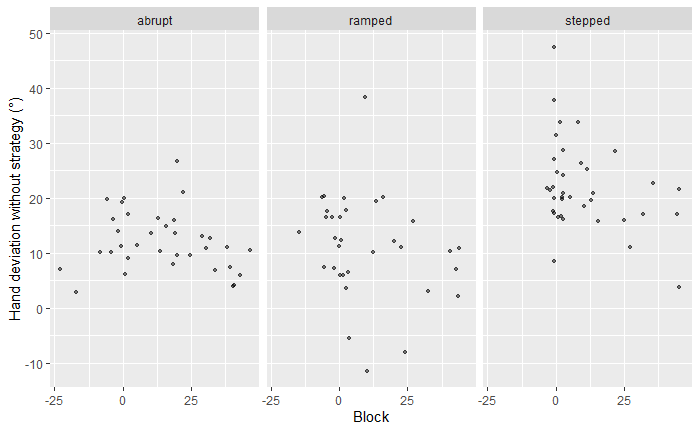

```r
# plot
p <- block_4_nocur %>%
  ggplot(aes(strategy, strat_0)) +
  geom_point(
    alpha = 0.5,
    size = 1
    ) +
  facet_grid(~exp)+
        xlab("Block") + ylab("Hand deviation without strategy (°)")

p
```

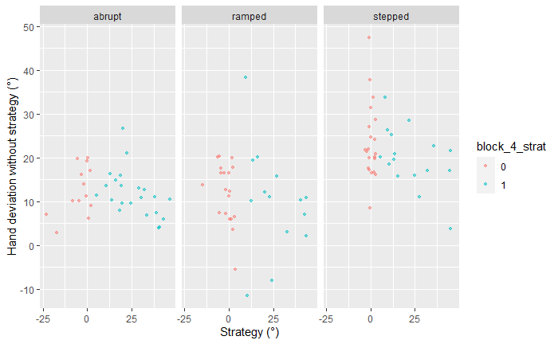

```r
# plot
p <- block_4_nocur %>%
  ggplot(aes(strategy, strat_0)) +
  geom_point(
    aes(colour = block_4_strat),
    alpha = 0.5,
    size = 1
    ) +
  facet_grid(~exp)+
        xlab("Strategy (°)") + ylab("Hand deviation without strategy (°)")

p
```

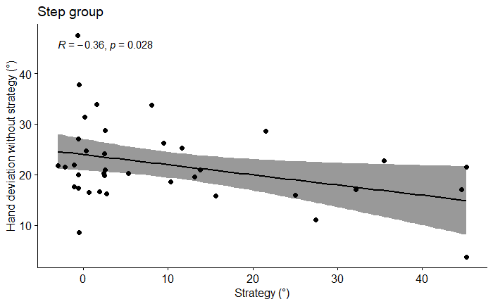

```r
p <- block_4_nocur %>%
  filter(exp == "stepped") %>%
  ggscatter(x = "strategy", y = "strat_0",
            title = "Step group",
          add = "reg.line", conf.int = TRUE,
          cor.coef = TRUE, cor.method = "pearson",
          xlab = "Strategy (°)", ylab = "Hand deviation without strategy (°)")
p
```

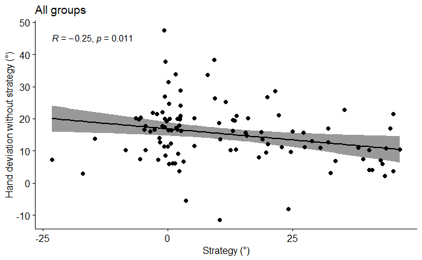

```r
p <- block_4_nocur %>%
  ggscatter(x = "strategy", y = "strat_0",
            title = "All groups",
          add = "reg.line", conf.int = TRUE,
          cor.coef = TRUE, cor.method = "pearson",
          xlab = "Strategy (°)", ylab = "Hand deviation without strategy (°)")
p
```

Does group have an effect on strategy use?

```r
block_4_strat_aov <- aov(strategy ~ exp, data = block_4_nocur)
print(summary(block_4_strat_aov), digits = 6)
```

```
             Df   Sum Sq Mean Sq F value  Pr(>F)
exp           2   517.68 258.842 0.96309 0.38516
Residuals   102 27413.79 268.763
```

```r
eta_squared(block_4_strat_aov)
```

```
For one-way between subjects designs, partial eta squared is equivalent to eta squared. Returning eta squared.
```

```
# Effect Size for ANOVA

Parameter | Eta2 |       95% CI
-------------------------------
exp       | 0.02 | [0.00, 1.00]

- One-sided CIs: upper bound fixed at [1.00].
```

```r
TukeyHSD(block_4_strat_aov)
```

```
  Tukey multiple comparisons of means
    95% family-wise confidence level

Fit: aov(formula = strategy ~ exp, data = block_4_nocur)

$exp
                     diff       lwr      upr     p adj
ramped-abrupt  -4.7915177 -14.25246 4.669426 0.4532287
stepped-abrupt -4.6340488 -13.82800 4.559906 0.4566252
stepped-ramped  0.1574689  -9.17856 9.493498 0.9991131
```

# 3 Reach training analysis

Use bl_corrected data

```r
training_summary_per_trial <- rot_training %>%
  group_by(exp, trial_num_cont) %>%
  summarise(mean_devs = mean(angular_dev), sd = sd(angular_dev),
            ci = vector_confint(angular_dev), .groups = "drop")

#training_summary$rotation_angle <- factor(training_summary$rotation_angle, levels=c("-15", "-30", "-45", "-60"))
training_summary_per_trial$trial_num_cont <- training_summary_per_trial$trial_num_cont - 66

# make trial sets factor
```

## 3.1 Init vs block 4 tatistics

Plot of relevant groups

```r
training_trial_sets_04 <- rot_training %>%
  filter(trial_set == 1 | trial_set == 3) %>%
  group_by(exp, ppt, trial_set) %>%
  summarise(angular_dev_mean = mean(angular_dev),
            sd = sd(angular_dev),
            ci = vector_confint(angular_dev),
            n = n(), .groups = "drop")
  # group_by(exp, trial_set) %>%
  # summarise(trial_set_mean = mean(angular_dev_mean),
  #           sd = sd(angular_dev_mean),
  #           ci = vector_confint(angular_dev_mean),
  #           n = n(), .groups = "drop")

head(training_trial_sets_04)
```

[output not shown]

```r
plot_desc_group_density(training_trial_sets_04, "trial_set", "angular_dev_mean", subgroup = "exp", title = "Training trial sets")
```

[output not shown]

### 3.1.1 Anova for the trial sets

```r
#performing a mixed effects model? (ezANOVA says it can't perform stuff on unbalanced data..)
temp_ANOVA <- training_trial_sets_04 %>%
  ezANOVA(wid = ppt,
        dv = angular_dev_mean,
        within = .(trial_set),
        between = exp,
        detailed = TRUE)

temp_ANOVA
```

[output not shown]

```r
bf_test <- anovaBF(angular_dev_mean ~ exp * trial_set + ppt, data = training_trial_sets_04, whichRandom = "ppt", progress=FALSE)
print(bf_test)
bayesfactor_inclusion(bf_test)
```

[output not shown]

```r
plot(bf_test)
```

[output not shown]

```r
training_final_trial_set <- training_trial_sets_04 %>%
  filter(trial_set == '3')
```

```r
#plot
plot_desc_group_density(training_final_trial_set, "exp", "angular_dev_mean", title = "Block 4 Adaptation")
```

[output not shown]

```r
# descriptives
training_final_trial_set %>%
  group_by(exp) %>%
  summarise(mean = mean(angular_dev_mean),
            norm_mean = mean(angular_dev_mean)/60,
            sd = sd(angular_dev_mean),
            ci = vector_confint(angular_dev_mean),
            n = n())
```

[output not shown]

```r
training_ANOVA <- aov(angular_dev_mean ~ exp, data = training_final_trial_set)

#show ANOVA + assumptions
print(summary(training_ANOVA), digits = 6)
eta_squared(training_ANOVA)
TukeyHSD(training_ANOVA)
```

[output not shown]

Bayes Factors

```r
print(test_bf)
bayesfactor_inclusion(test_bf)
print(tmp_bf_abr_ramp)
print(tmp_bf_stp_ramp)
print(tmp_bf_stp_abr)
```

[output not shown]

## 3.3 End of block 1 learning

```r
training_trial_sets_1 <- rot_training %>%
  filter(trial_set == 2) %>%
  group_by(exp, ppt, trial_set) %>%
  summarise(angular_dev_mean = mean(angular_dev),
            sd = sd(angular_dev),
            ci = vector_confint(angular_dev),
            n = n(), .groups = "drop")
  # group_by(exp, trial_set) %>%
  # summarise(trial_set_mean = mean(angular_dev_mean),
  #           sd = sd(angular_dev_mean),
  #           ci = vector_confint(angular_dev_mean),
  #           n = n(), .groups = "drop")

head(training_trial_sets_1)
```

[output not shown]

```r
t.test(angular_dev_mean ~ exp, data = training_trial_sets_1)
print(tmp_bf_abr_ramp)
```

[output not shown]

# 4 Combining all data

Plotting all data

```r
# make a summary df
rot_all_summary <- rot_all %>%
  group_by(exp, trial_num_cont, strat_use) %>%
  summarise(mean = mean(angular_dev),
            sd = sd(angular_dev),
            ci = vector_confint(angular_dev),
            n = n(), .groups = "drop")
```

plot

```r
p <- rot_all %>%
  ggplot(aes(trial_num_cont, angular_dev, colour = exp, shape = strat_use)) +
  geom_point(alpha = 0.04)+
  geom_point(data = rot_all_summary, aes(y = mean)) +
  scale_shape_manual(values=c(20, 2))+
  # stat_summary(fun=mean, geom="point", size=3, color="red") +
  theme_minimal() +
  theme(panel.grid.major.y = element_line(colour = "#CCCCCC")) +
  scale_y_continuous(limits = c(-20, 90)) +
  ggtitle("All data")

p

# ggsave(p, height = 9, width = 16, device = "svg", filename = "data/paper_figs/all_reaches.svg")
```

[output not shown]

Repeat for normalized angular deviations

```r
rot_norm_summary <- rot_all %>%
  group_by(exp, trial_num_cont, strat_use) %>%
  summarise(mean = mean(norm_angular_dev),
            sd = sd(norm_angular_dev),
            ci = vector_confint(norm_angular_dev),
            n = n(), .groups = "drop")
```

plot

```r
p <- rot_all %>%
  ggplot(aes(trial_num_cont, norm_angular_dev, colour = exp, shape = strat_use)) +
  geom_point(alpha = 0.04) +
  geom_point(data = rot_norm_summary, aes(y = mean)) +
  scale_shape_manual(values=c(20, 2))+
  # stat_summary(fun=mean, geom="point", size=3, color="red") +
  theme_minimal() +
  theme(panel.grid.major.y = element_line(colour = "#CCCCCC")) +
  scale_y_continuous(limits = c(-0.5, 1.5)) +
  ggtitle("All data")

p

# ggsave(p, height = 9, width = 16, device = "svg", filename = "data/paper_figs/all_reaches_norm.svg")
```

[output not shown]

# 4 Last block of stepped

```r
ind_nocur_stepped_detailed_summary <- rot_nocur %>%
  filter(exp == "stepped", block_num == 4, strat_use == 0) %>%
  group_by(ppt, block_num_detailed) %>%
  summarise(ind_mean = mean(angular_dev),
            sd = sd(angular_dev),
            ci = vector_confint(angular_dev),
            n = n(), .groups = "drop")
ind_nocur_stepped_detailed_summary$block_num_detailed <- factor(ind_nocur_stepped_detailed_summary$block_num_detailed)
group_nocur_stepped_detailed_summary <- ind_nocur_stepped_detailed_summary %>%
  group_by(block_num_detailed) %>%
  summarise(mean_devs = mean(ind_mean),
            sd = sd(ind_mean),
            ci = vector_confint(ind_mean),
            n = n(), .groups = "drop")

group_nocur_stepped_detailed_summary
```

[output not shown]

```r
#plot
plot_desc_group_density(ind_nocur_stepped_detailed_summary, "block_num_detailed", "ind_mean", title = "Block 4 Stepped - no decay")
```

[output not shown]

# 5 Decay Slopes

```r
    # load in the DECAY data
    data <- load_bl_corrected("data/bl_corrected/bl_corrected_data.csv",
        type = "nocursor"
    )

    # add a column with 1-9 repeating
    data <- data %>%
        mutate(trial_in_block = rep(1:9, length.out = nrow(data)))

    # select useful columns
    data <- data %>%
        select(exp, ppt, strat_use, block_num, trial_in_block, angular_dev) %>%
        group_by(exp, ppt, strat_use, block_num, trial_in_block) %>%
        summarise(
            angular_dev_m = mean(angular_dev),
            n = n()
        ) %>%
        pivot_wider(
            names_from = strat_use,
            names_prefix = "strat_",
            values_from = angular_dev_m
        ) %>%
        mutate(strategy = strat_1 - strat_0) %>%
        pivot_longer(
            cols = 6:8,
            names_to = "strat_use", values_to = "angular_dev"
        )

    # in strat_use, replace "strat_0" with "Without Strategy"
    # and "strat_1" with "With Strategy",
    # and "strategy" with "Explicit Strategy"
    data <- data %>%
        mutate(strat_use = ifelse(strat_use == "strat_0", "Without Strategy",
            ifelse(strat_use == "strat_1", "With Strategy",
                ifelse(strat_use == "strategy", "Explicit Strategy",
                    strat_use
                )
            )
        ))

    # make strat_use a factor
    data <- data %>%
        mutate(strat_use = factor(strat_use,
            levels = c("Without Strategy", "With Strategy", "Explicit Strategy")
        ))

    # make individual table
    data_ind <- data %>%
        group_by(exp, ppt, strat_use, block_num) %>%
        summarise(
            ind_mean = mean(angular_dev),
            sd = sd(angular_dev),
            ci = vector_confint(angular_dev),
            slope = decay_fit(trial_in_block, angular_dev)[2],
            intercept = decay_fit(trial_in_block, angular_dev)[1],
            n = n(), .groups = "drop"
        )

    # make group table
    data_group <- data_ind %>%
        group_by(exp, strat_use, block_num) %>%
        summarise(
            group_slope_mean = mean(slope),
            slope_ci = vector_confint(slope),
            group_intercept_mean = mean(intercept),
            intercept_ci = vector_confint(intercept),
            n = n(), .groups = "drop"
        )

    # add a nested vector column
    data_group <- data_group %>%
        mutate(trial_in_block = list((c(1:9))))

    # unnest
    data_group <- data_group %>%
        unnest_longer(trial_in_block)

    # make a column with inferred y values
    data_group <- data_group %>%
        mutate(y_inferred = group_slope_mean * trial_in_block +
            group_intercept_mean)
```

## 5.1 Implicit aftereffect decay

```r
#performing a mixed effects model? (ezANOVA says it can't perform stuff on unbalanced data..)
temp_ANOVA <- data_ind %>%
  filter(strat_use == 'Without Strategy') %>%
  ezANOVA(wid = ppt,
        dv = slope,
        within = .(block_num),
        between = exp,
        detailed = TRUE)

#show and ANOVA + assumptions
print(temp_ANOVA$ANOVA)
```

[output not shown]

```r
# this is the classical anova equivalent -- numbers are the same as above
summary(aov(slope ~ exp*block_num + Error(ppt/(exp*block_num)),
            data=filter(data_ind, strat_use == 'Without Strategy') ))
```

[output not shown]

```r
# mixed effects bayes anova
bf = anovaBF(slope ~ exp*block_num + ppt,
             data=filter(data_ind, strat_use == 'Without Strategy'),
             whichRandom="ppt")
print(bf)
bayesfactor_inclusion(bf)
```

[output not shown]

## 5.2 With-strategy reach decay

```r
#performing a mixed effects model? (ezANOVA says it can't perform stuff on unbalanced data..)
temp_ANOVA <- data_ind %>%
  filter(strat_use == 'With Strategy') %>%
  ezANOVA(wid = ppt,
        dv = slope,
        within = .(block_num),
        between = exp,
        detailed = TRUE)

#show and ANOVA + assumptions
print(temp_ANOVA$ANOVA)
```

[output not shown]

```r
# this is the classical anova equivalent -- numbers are the same as above
summary(aov(slope ~ exp*block_num + Error(ppt/(exp*block_num)),
            data=filter(data_ind, strat_use == 'With Strategy') ))
```

[output not shown]

```r
# mixed effects bayes anova
bf = anovaBF(slope ~ exp*block_num + ppt,
             data=filter(data_ind, strat_use == 'With Strategy'),
             whichRandom="ppt")
print(bf)
bayesfactor_inclusion(bf)
```

[output not shown]

## 5.3 Explicit strategy use decay

```r
#performing a mixed effects model? (ezANOVA says it can't perform stuff on unbalanced data..)
temp_ANOVA <- data_ind %>%
  filter(strat_use == 'Explicit Strategy') %>%
  ezANOVA(wid = ppt,
        dv = slope,
        within = .(block_num),
        between = exp,
        detailed = TRUE)
#show and ANOVA + assumptions
print(temp_ANOVA$ANOVA)
```

[output not shown]

```r
# mixed effects bayes anova
bf <- anovaBF(slope ~ exp*block_num + ppt,
             data=filter(data_ind, strat_use == 'Explicit Strategy'),
             whichRandom="ppt")
print(bf)
bayesfactor_inclusion(bf)
```

[output not shown]

## 5.4 Block agnostic implicit aftereffects decay

```r
# make individual table
data_blockcollapsed <- data %>%
        group_by(exp, ppt, strat_use) %>%
        summarise(
            ind_mean = mean(angular_dev),
            sd = sd(angular_dev),
            ci = vector_confint(angular_dev),
            slope = decay_fit(trial_in_block, angular_dev)[2],
            intercept = decay_fit(trial_in_block, angular_dev)[1],
            n = n(), .groups = "drop"
        )
```

Descriptive stats

```r
# descriptives
data_blockcollapsed %>%
  filter(strat_use == 'Without Strategy') %>%
  group_by(exp) %>%
  summarise(mean = mean(slope),
            sd = sd(slope),
            ci = vector_confint(slope),
            n = n())
```

[output not shown]

```r
#performing a mixed effects model? (ezANOVA says it can't perform stuff on unbalanced data..)
temp_ANOVA <- data_blockcollapsed %>%
  filter(strat_use == 'Without Strategy') %>%
  ezANOVA(wid = ppt,
        dv = slope,
        between = exp,
        detailed = TRUE)
```

```r
#show and ANOVA + assumptions
print(temp_ANOVA$ANOVA)
```

[output not shown]

```r
# mixed effects bayes anova
bf = anovaBF(slope ~ exp,
             data=filter(data_blockcollapsed, strat_use == 'Without Strategy'))
print(bf)
bayesfactor_inclusion(bf)
```

[output not shown]

non-ez anova

```r
temp_ANOVA <- aov(slope ~ exp, data = filter(data_blockcollapsed, strat_use == 'Without Strategy'))

#show ANOVA + assumptions
print(summary(temp_ANOVA), digits = 6)
eta_squared(temp_ANOVA)
TukeyHSD(temp_ANOVA)
```

[output not shown]

```r
print(tmp_bf_abr_ramp)
print(tmp_bf_stp_ramp)
print(tmp_bf_stp_abr)
```

[output not shown]

# 6 Movement time differences

```r
# isolate trials up to 46 trials
early_trial_df <- rot_all %>%
  mutate(
    trial_num_cont = case_when(
      exp == "ramped" ~ (trial_num_cont - 18),
      TRUE ~ trial_num_cont
      )
    ) %>%
  filter(trial_num_cont <= 46) %>%
  mutate(
    move_time = case_when(
      ((exp == "abrupt") & (time_s > 1000)) ~ (lead(time_s) - time_s),
      TRUE ~ time_s
      )
    ) %>%
  filter(trial_num_cont <= 40)

# plot
# group by experiment and trial_num_cont
# then make a summary df
data_group <- early_trial_df %>%
    group_by(exp, trial_num_cont) %>%
    summarise(
        group_mean = mean(move_time),
        sd = sd(move_time),
        ci = vector_confint(move_time),
        n = n(), .groups = "drop"
    )

# set up the plot
p <- data_group %>%
    ggplot(aes(
        x = trial_num_cont, y = group_mean,
        color = exp, group = exp
    ))

# add classic theme
p <- p + theme_classic()

# add the confidence intervals and data
p <- p + geom_ribbon(aes(
    x = trial_num_cont,
    ymin = group_mean - ci,
    ymax = group_mean + ci,
    fill = exp,
    group = exp,
), colour = NA, alpha = 0.3) +
    geom_line(aes(colour = exp))

# set x and y axis labels
p <- p +
    labs(
        x = "Block",
        y = "Trial time (s)"
    )
p
```

[output not shown]